# Laboratorio 4.1: Clustering I

**Autores:** Fran Zautzik

**Fecha:** Octubre 2023

## ============= Declaración de compromiso ético =============

Nosotros ****Andrés Calderón (S1) y Franco González (S1)**** , declaramos que realizamos de manera grupal los pasos de la presente actividad. También declaramos no incurrir en copia, ni compartir nuestras respuestas con otras personas ni con otros grupos. Por lo que, ratificamos que las respuestas son de nuestra propia confección y reflejan nuestro propio conocimiento.

# Instrucciones

1. Trabajen en equipos de dos personas. Salvo excepciones, no se corregirá entregas con menos de dos integrantes.
2. Modifiquen este archivo `.ipynb` agregando sus respuestas donde corresponda.
3. Cuando finalicen el laboratorio, **generen un archivo HTML** usando jupyter (ver tutorial 3) y súbanlo a U-Cursos. El laboratorio debe ser entregado sólo por 1 integrante. Si se entrega por más de un integrante, se revisará cualquiera de éstos.

Para esta Laboratorio vamos usar dos métodos de clustering, K-means y DBSCAN, sobre el clásico dataset de flores Iris. Note que normalmente hacer clustering sobre datos de los que ya sabemos las clases (en este caso la especiede flor) no hace sentido, sin embargo usaremos este dataset para encontrar dichos grupos de manera no supervisada a modo de ejemplo.

Ejecute las siguientes celdas para importar el dataset iris desde sci-kit learn.

```python
import pandas as pd
import matplotlib.pyplot as plt
from sklearn import datasets

iris = datasets.load_iris()
df = pd.DataFrame(data=iris.data, columns=['SepalLength', 'SepalWidth', 'PetalLength', 'PetalWidth'])
df['Species'] = iris.target
```

Ahora inspecionamos rapidamente los datos y su estructura:

```python
df.sample(5)
```

|  | SepalLength | SepalWidth | PetalLength | PetalWidth | Species |
| --- | --- | --- | --- | --- | --- |
| 27 | 5.2 | 3.5 | 1.5 | 0.2 | 0 |
| 76 | 6.8 | 2.8 | 4.8 | 1.4 | 1 |
| 140 | 6.7 | 3.1 | 5.6 | 2.4 | 2 |
| 145 | 6.7 | 3.0 | 5.2 | 2.3 | 2 |
| 78 | 6.0 | 2.9 | 4.5 | 1.5 | 1 |

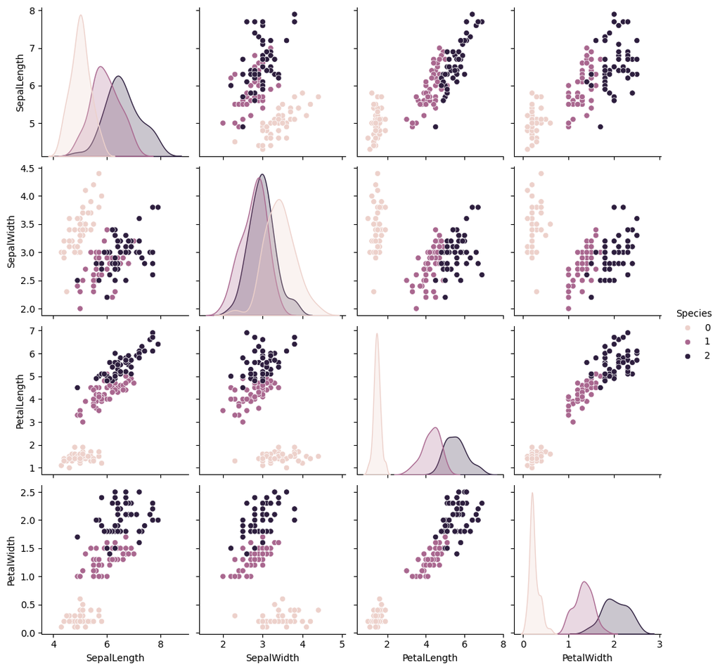

```python
import seaborn as sns

sns.pairplot(df, hue='Species')
```

Y ahora definimos el conjunto de de datos solo con los atributos a usar mas adelante en el clustering.

```python
X = df.drop('Species', axis=1)
```

**1.** Importe y ejecute sobre los datos el algoritmo K-means. Use el parametro `n_clusters=3`.

```python
#Respuesta
from sklearn.cluster import KMeans

kmeans = KMeans(n_clusters=3).fit(X)
```

```
c:\Users\ninja\OneDrive\Escritorio\Academicos\DCC\Mineria de Datos\venv\lib\site-packages\sklearn\cluster\_kmeans.py:1416: FutureWarning: The default value of `n_init` will change from 10 to 'auto' in 1.4. Set the value of `n_init` explicitly to suppress the warning
  super()._check_params_vs_input(X, default_n_init=10)
```

**2.** Importe y ejecute sobre los datos el algoritmo DBSCAN. Use los parametros por defecto.

```python
#Respuesta
from sklearn.cluster import DBSCAN

dbscan = DBSCAN().fit(X)
```

**3.** Aplique PCA sobre los datos para reducir la dimensionalidad a 2.

```python
#Respuesta
from sklearn.decomposition import PCA

pca = PCA(n_components=2).fit(X)
x_pca = pca.transform(X)
```

**4.** Haga tres scatterplot de los datos reducidos. En uno coloree cada ejemplo según la especie, en otro segun los clusters generados por K-means y es otro segun los clusters generados por DBSCAN.

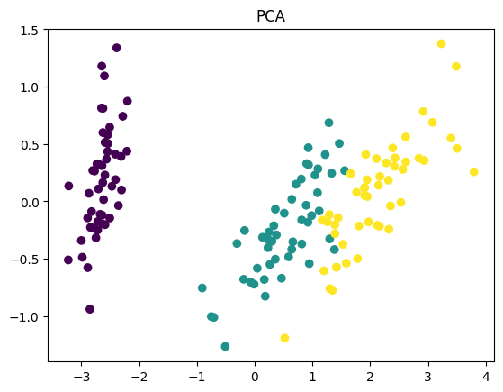

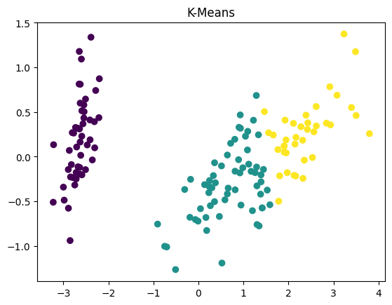

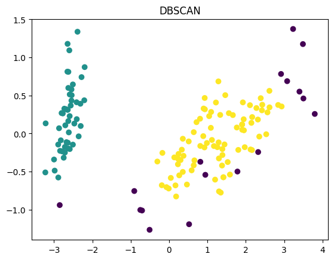

```python
#Respuesta
# PCA
plt.scatter(x_pca[:,0], x_pca[:,1], c=iris.target)
plt.title("PCA")
plt.show()

# K-Means
plt.scatter(x_pca[:, 0], x_pca[:, 1], c=kmeans.labels_)
plt.title("K-Means")
plt.show()

# DBSCAN
plt.scatter(x_pca[:,0], x_pca[:,1], c=dbscan.labels_)
plt.title("DBSCAN")
plt.show()
```

**6.** Responda ¿Porque los resultados obtenidos con ambos modelos son diferentes y cual captura mejor las especies? Justifique mencionando la estructura que tienen los grupos y como funcionan los algoritmos.

Respuesta:

El modelo K-Means genera 3 centroides en este caso, los cuales toma como centro de los clusters para separar el espacio ,mientras que el DBSCAN genera clusters basado en la densidad de datos para un radio particular, y que deja como outliers aquellos que no quedaron en ningún cluster, por lo anterior el DBSCAN no es capaz de diferenciar dos de los tres grupos de flores que hay pues existen dos que están relativamente solapados, influyendo en el resultado del clustering. Como el resultado del K-Means se asemeja más a los valores reales, entonces es este el modelo que captura mejor las especies de flores, en parte porque forzamos a que separara los datos en tres clusters por lo que logra de mejor manera que DBSCAN separar este conjunto de datos, además de que justo la disposición de datos en el espacio es bastante circular lo cual faverece al K-Means.